# Home Work

Nikita Latyshev

December 2022

# Задание: Виды анализа и R Markdown.

#### Был выдан вариант со следующими анализами:

1. Разведочный
2. Механистический

##### **Разведочный анализ**

- В качестве примера была рассмотрена [данная статья](https://cyberleninka.ru/article/n/obrabotka-i-razvedochnyy-analiz-chislovyh-massivov-dannyh).

Разведочный анализ зачастую связывают с нахождением общих закономерностей, распределений и аномалий, а также построением начальных моделей, зачастую с использованием инструментов визуализации. При выполнении данный действий мы выявляем в данных значимо отличающиеся значения (выбросы).

В данной статье как раз и применяется с помощью критериев Диксона, r-статистики, Граббса и других. К примеру в алгоритме с критерием Диксона:

> …после ранжирования исходной выборки в порядке не убывания рассчитывают фактическое значение критерия.

А фактическое значение критерия высчитывается с помощью следующей формул:

- $r_{n} = \frac{x_{n} - \tilde{x}}{D_{x}\sqrt{\frac{n-1}{n}}}$ - при подозрении $x_{n}$ на аномальный максимум;
- $r_{1} = \frac{\tilde{x} - x_{1}}{D_{x}\sqrt{\frac{n-1}{n}}}$ - при подозрении $x_{1}$ на аномальный минимум.

В данных формулах:

- $\tilde{x}$ - среднее по выборке (с учётом анализируемого значения);
- $D_{x}$ - дисперсия выборки (с учётом анализируемого значения).

##### **Механистический анализ**

- В качестве примера была рассмотрена [данная статья](https://cyberleninka.ru/article/n/opyt-primeneniya-mehanisticheskogo-modelirovaniya-parametrov-mnogofaznogo-potoka-v-stvole-skvazhin-achimovskih-otlozheniy).

Механистический анализ в большей степени связан с фундаментальной наукой,исследованиями и разработками, и к нему больше подходит термин «моделирование», чем «анализ».

В данной статье как раз таки рассматривается применение механистического моделирования в отечественной газовой промышленности.

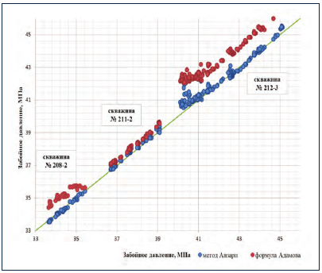

Причём во время Механистического моделирования использовалась приведённая ниже небольшая часть таблицы с массивом данных расчёта забойного давления по методу Анзари и формуле Адамова.

|  | № 208-2 |  |  | №211-2 |  |  | № 212-3 |  |
| --- | --- | --- | --- | --- | --- | --- | --- | --- |
| $P_{факт}$ | Анзари | Адамов | $P_{факт}$ | Анзари | Адамов | $P_{факт}$ | Анзари | Адамов |
| 35,42 | 35,43 | 35,65 | 38,39 | 38,52 | 38,78 | 44,78 | 44,94 | 45,47 |
| … | … | … | … | … | … | … | … | … |